# Project: European Soccer Data Analysis

- Introduction
- Data Wrangling
- Exploratory Data Analysis
- Conclusions

## Introduction

> I will be analyzing the european soccer database, performing explanatory analysis and answering below questions:
> 1. How many players play with left foot vs right foot?
> 2. Analyze the Defence Aggression statistics in the Team Attributes table.
> 3. Team goals improvement or deterioration.

```python
# Use this cell to set up import statements for all of the packages that you
#   plan to use.

import pandas as pd
import numpy as np
import matplotlib.pyplot as plt
%matplotlib inline
import seaborn as sns
sns.set_style('darkgrid')
import sqlite3
```

## Data Wrangling

### General Properties

```python
# Load your data and print out a few lines. Perform operations to inspect data
#   types and look for instances of missing or possibly errant data.

# Opening connection to read the Database tables
cnx = sqlite3.connect(r'database.sqlite')
```

```python
#analyzig player data by joining Player table and Player Attributes table
df_player = pd.read_sql_query("select player.player_name, player.birthday,p.* from player join Player_Attributes as p on player.player_api_id = p.player_api_id",cnx)
```

```python
df_player['preferred_foot'].isnull().sum() #remove the NaN values for clear analysis.
```

```
836
```

```python
#To analyze the increase and descrease in goals for teams over a period of time .'Goal data' for each team in a season we join the Team table, match table and league table
df_goal = pd.read_sql_query("""select sum(goals) Goals_scored, season, team_name, league_name from (
select ht.team_long_name team_name, lg.name league_name, sum(home_team_goal) goals, m.season
from match m
	join team ht on m.home_team_api_id = ht.team_api_id
	join league lg on m.league_id = lg.id
group by m.season, lg.name, ht.team_long_name
UNION
select aw.team_long_name,lg.name, sum(away_team_goal) goals , m.season
from match m
	join team aw on m.away_Team_api_id = aw.team_api_id
	join league lg on m.league_id = lg.id
group by m.season, lg.name, aw.team_long_name
) a
group by season,league_name, team_name
order by league_name asc, sum(goals)""",cnx)
```

```python
df_goal.head(1)
df_goal['season'].max() # to define a period. Get the data available for latest season
df_goal['season'].min() # to define a period. Get the data available for oldest season
```

```
'2008/2009'
```

```python
#find the total goals scored by teams in 2008/2009 season and 2015/2016 season.
df_0809_season=df_goal.query('season == "2008/2009"').groupby(['team_name']).sum()['Goals_scored']
df_1516_season = df_goal.query('season == "2015/2016"').groupby(['team_name']).sum()['Goals_scored']
```

```python
#how much have teams improved in goals from 2008/2009 to 2015/2016
inc = df_1516_season - df_0809_season
inc #we will have to remove the Null values which determine that the teams were missing in either season.
```

```
team_name
1. FC Köln                       3.0
1. FSV Mainz 05                  NaN
AC Bellinzona                    NaN
ADO Den Haag                     7.0
AJ Auxerre                       NaN
AS Monaco                       16.0
AS Nancy-Lorraine                NaN
AS Saint-Étienne                 2.0
AZ                               4.0
Aberdeen                        21.0
Académica de Coimbra             4.0
Ajax                             7.0
Amadora                          NaN
Angers SCO                       NaN
Arka Gdynia                      NaN
Arsenal                         -3.0
Aston Villa                      0.0
Atalanta                        -4.0
Athletic Club de Bilbao         11.0
Atlético Madrid                -17.0
BSC Young Boys                  -7.0
Bayer 04 Leverkusen             -3.0
Beerschot AC                     NaN
Blackburn Rovers                 NaN
Boavista FC                      NaN
Bologna                        -10.0
Bolton Wanderers                 NaN
Borussia Dortmund               22.0
Borussia Mönchengladbach        28.0
Bournemouth                      NaN
                                ...
Termalica Bruk-Bet Nieciecza     NaN
Tondela                          NaN
Torino                          15.0
Tottenham Hotspur               24.0
Toulouse FC                      0.0
Trofense                         NaN
Tubize                           NaN
UD Almería                       NaN
```

[output cut: 8 more lines]

```
Villarreal CF                  -17.0
Vitesse                         14.0
Vitória Guimarães               13.0
Vitória Setúbal                 19.0
Waasland-Beveren                 NaN
Watford                          NaN
West Bromwich Albion            -2.0
West Ham United                 23.0
Widzew Łódź                      NaN
Wigan Athletic                   NaN
Willem II                        0.0
Wisła Kraków                    -8.0
Zagłębie Lubin                   NaN
Śląsk Wrocław                  -26.0
Name: Goals_scored, Length: 243, dtype: float64
```

```python
# get detailed match data to perform further analysis on matches based on leagues
df_match = pd.read_sql_query("select m.id, c.name as country_name, l.name as league_name,m.season,m.stage,home_team_goal,away_team_goal from match m join Country c on m.country_id = c.id join league l on m.league_id = l.id  ", cnx)
```

```python
# TO check if the number of teams qualified for the leagues change over a period of time.
#This doesn't vary a lot hence not a useful graph to plot
df_match.groupby(['season','league_name']).id.count()
```

```
season     league_name
2008/2009  Belgium Jupiler League      306
           England Premier League      380
           France Ligue 1              380
           Germany 1. Bundesliga       306
           Italy Serie A               380
           Netherlands Eredivisie      306
           Poland Ekstraklasa          240
           Portugal Liga ZON Sagres    240
           Scotland Premier League     228
           Spain LIGA BBVA             380
           Switzerland Super League    180
2009/2010  Belgium Jupiler League      210
           England Premier League      380
           France Ligue 1              380
           Germany 1. Bundesliga       306
           Italy Serie A               380
           Netherlands Eredivisie      306
           Poland Ekstraklasa          240
           Portugal Liga ZON Sagres    240
           Scotland Premier League     228
           Spain LIGA BBVA             380
           Switzerland Super League    180
2010/2011  Belgium Jupiler League      240
           England Premier League      380
           France Ligue 1              380
           Germany 1. Bundesliga       306
           Italy Serie A               380
           Netherlands Eredivisie      306
           Poland Ekstraklasa          240
           Portugal Liga ZON Sagres    240
                                      ...
2013/2014  Germany 1. Bundesliga       306
           Italy Serie A               380
           Netherlands Eredivisie      306
           Poland Ekstraklasa          240
           Portugal Liga ZON Sagres    240
           Scotland Premier League     228
           Spain LIGA BBVA             380
           Switzerland Super League    180
```

[output cut: 8 more lines]

```
           Scotland Premier League     228
           Spain LIGA BBVA             380
           Switzerland Super League    180
2015/2016  Belgium Jupiler League      240
           England Premier League      380
           France Ligue 1              380
           Germany 1. Bundesliga       306
           Italy Serie A               380
           Netherlands Eredivisie      306
           Poland Ekstraklasa          240
           Portugal Liga ZON Sagres    306
           Scotland Premier League     228
           Spain LIGA BBVA             380
           Switzerland Super League    180
Name: id, Length: 88, dtype: int64
```

```python
# Read data for players postion that is available on Kaggel.
df_pos = pd.read_csv('player_positions.csv')
#df_pos.query('playerID == "30829"')
```

```python
df_team = pd.read_sql_query("select team.team_long_name,team.team_short_name,Team_Attributes.* from Team join Team_Attributes on team.team_api_id = Team_Attributes.team_api_id",cnx)
```

```python
# After discussing the structure of the data and any problems that need to be
#   cleaned, perform those cleaning steps in the second part of this section.

# We can drop 'id' since it is incremental value in the databse and 'buildUpPlayDribbling' column since more than 50% of data is null
df_team.drop(['id','buildUpPlayDribbling'],axis =1, inplace = True)
```

```python
#dropped null rows
df_player.dropna(axis = 0,inplace = True)
```

```python
#verified to validate the null values are deleted
df_player['preferred_foot'].isnull().sum()
```

```
0
```

```python
inc.dropna(axis =0,inplace = True) #cleaning the Null valuess to plot the improvement of teams which were present in both seasons.
```

```python
inc.isnull().any()
```

```
False
```

Analyzing to see if the teams have improved based on speed from 2010 to 2012

[figure not shown]

```python
df_team.query('date == "2010-02-22 00:00:00"').groupby(['date','team_long_name']).mean()['buildUpPlaySpeed'].plot(alpha= 0.7, kind= 'hist', label = '2010-02-22');
df_team.query('date == "2012-02-22 00:00:00"').groupby(['date','team_long_name']).mean()['buildUpPlaySpeed'].plot(alpha= 0.7, kind= 'hist', label = '2015-02-22');
plt.legend()
```

Based on the speed rating we can analyze which teams/leagues play faster or slower football in terms of pace.

## Exploratory Data Analysis

### Research Question 1 - Number of players that are right footed vs left footed

```python
#find the right foot and left foot players
Right = df_player.query('preferred_foot == "right"').player_api_id.nunique()
Right

Left = df_player.query('preferred_foot == "left"').player_api_id.nunique()
Left
```

```
3048
```

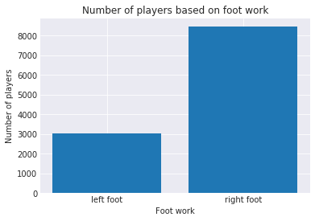

```python
#plot the above analyis
locations = [1,2]
labels = ['left foot','right foot']
height = [Left,Right]
plt.bar(labels,height)
plt.title('Number of players based on foot work')
plt.xlabel('Foot work')
plt.ylabel('Number of players');
```

### Research Question 2 - Find the teams that improved or deteriorated in hitting goals!

```python
inc.min()
inc.idxmin() # team that declined and made the least goal in 2015/2016 as compared to 2008/2009
```

```
'Real Betis Balompié'
```

```python
inc.max()
inc.idxmax() #team that improved and made the most goal 2008/2009 season to 2015/2016 season
```

```
'Paris Saint-Germain'
```

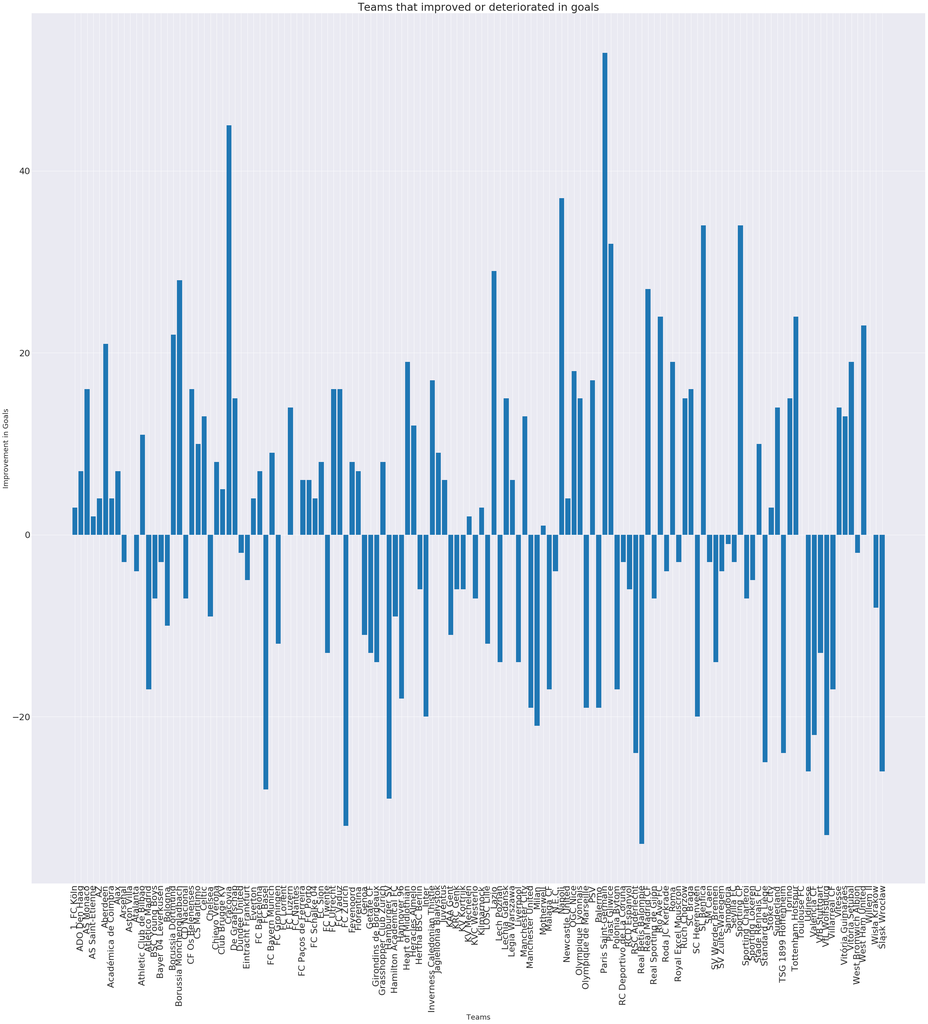

```python
import matplotlib.pyplot as plt
plt.rcParams.update({'font.size': 22})
plt.subplots(figsize = (40,40))
plt.bar(inc.index,inc);
plt.title('Teams that improved or deteriorated in goals')
plt.xlabel('Teams',fontsize =18)
plt.ylabel('Improvement in Goals',fontsize =18)
plt.xticks(rotation=90);
```

### Research Question 3 - Teams categorized by defence Aggression

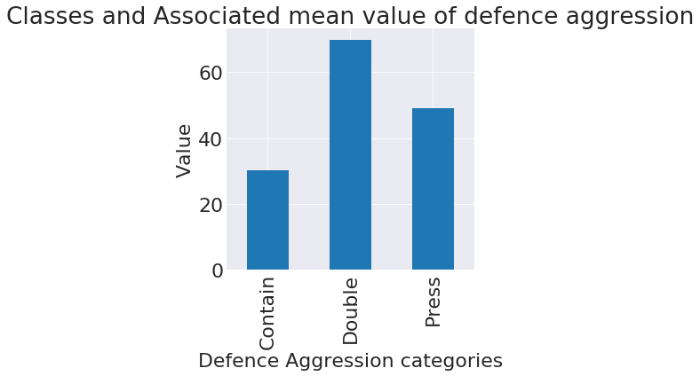

```python
#analyze the defence aggresssion statistics used within the teams
df_team.groupby(['defenceAggressionClass']).mean()['defenceAggression'].plot(kind ='bar',figsize=(5,5),title= 'Classes and Associated mean value of defence aggression')
plt.xlabel('Defence Aggression categories')
plt.ylabel('Value');
```

## Conclusions

> I found the biggest limitation in the dataset was to group the team attributes tabel to the player tabel because the team attributes has 20 coloumns on players and the join would become very compliated to identify single player statistics based on team performance.

> I have successfully able to graph:
> 1. The number of players that are left footed and right footed in the given dataset.
> 2. Improvement of team goals in the defined timeframe.
> 3. Understood what are the different kinds of Defence agression class that can later help to calculate the qualifying team attributes.

```python
from subprocess import call
call(['python', '-m', 'nbconvert', 'Investigate_a_Dataset.ipynb'])
```

```
0
```